# **Agenda**

### 1. Introduction

### 2. Categorical plots

### 3. Quantitative plots

### 4. Distributions plots

### 5. Relational plots

### 6. Styling

# introduction

> **what is data visualzation ?**
- Data visualization is the graphical representation of information and data. by using visual elements like charts, graphs, and maps.
- data visualization is used to interpret and gain insight into large amounts of data. This is achieved through visual representations, often interactive, of raw data.

> **Is data visualization essential and why must I do it?**

yes it is important that is because it :

- gives us a clear idea of what the information means by giving it visual context.
- shows Correlations in Relationships
- shows Trends Over Time.
- Find Patterns.
- shows the Frequency.

> **what are the types of data ?**
- **Quantitative**
- **Categorical**

> **what are Categorical plots ?**
- Bar plot
- count plot
- Pie Graph
- Box plot
- Point plot

> **what are Quantitative plots ?**
- line Graph
- Scatter plot
- regression plot
- Histogram

> **what are distributions plots ?**
- Histogram
- Box plot
- Violin plot
- joint plot
- Scatter plot

> **what are relational plots ?**
- Scatter plot
- heatmap plot
- regression plot

> **what is seaborn ?**
- Seaborn is a library mostly used for statistical plotting in Python. It is built on top of Matplotlib and provides beautiful default styles and color palettes to make statistical plots more attractive.

**before starting in plots we need to explain "hue"**

- the hue parameter determines which column in the data frame should be used for colour encoding
- it color the column that you passed to it and if you want to change order or color of each value you can do it using:

**hue_order**

- it takes a list of values that set the order of the values
- if you want to change the color use :

**palette**

- first create a dictionary that contain the color of each value and name it "hue_color"
- second pass the dictionary as a parameter to palette

**here is a color platte codes**

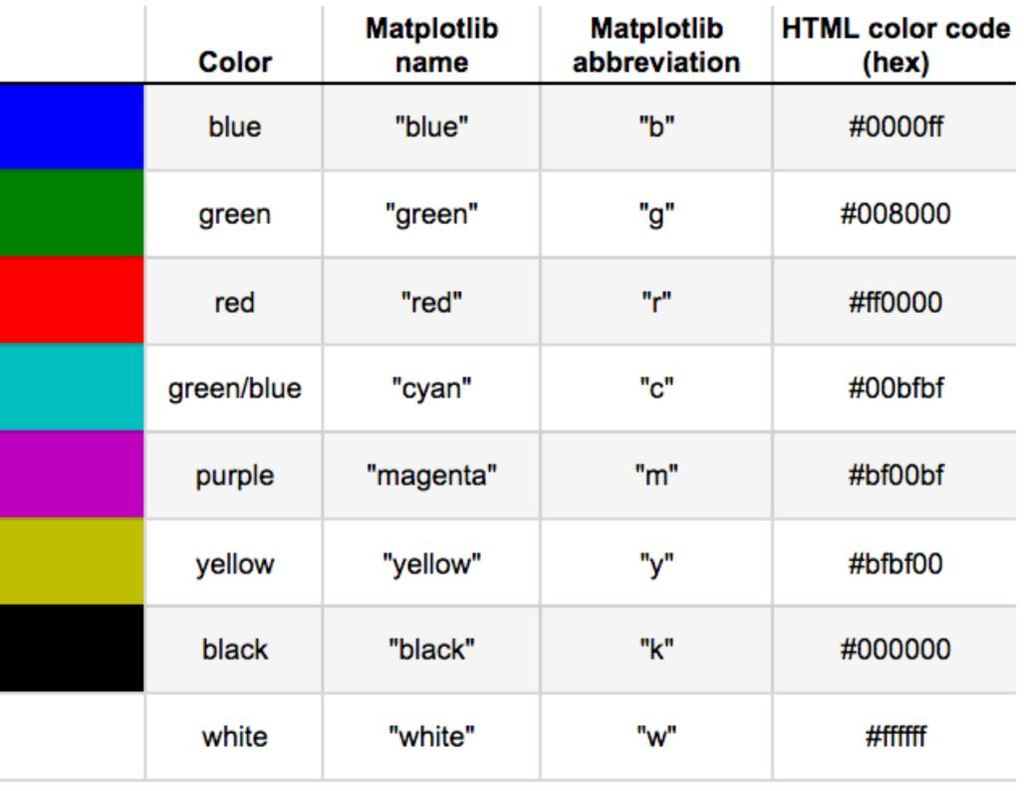

## note

> **data must be tidy and cleaned before starting visualisation**

### importing libraries

```python
# impoting libraries that we will use
import matplotlib.pyplot as plt
import seaborn as sns
import pandas as pd     #sns refered to  samuel norman seaborn
import numpy as np
```

```python
# seaborn has function called ----> sns.load_dataset("")
penguins = sns.load_dataset('penguins')
penguins.head()
```

|  | species | island | bill_length_mm | bill_depth_mm | flipper_length_mm | body_mass_g | sex |
| --- | --- | --- | --- | --- | --- | --- | --- |
| 0 | Adelie | Torgersen | 39.1 | 18.7 | 181.0 | 3750.0 | Male |
| 1 | Adelie | Torgersen | 39.5 | 17.4 | 186.0 | 3800.0 | Female |
| 2 | Adelie | Torgersen | 40.3 | 18.0 | 195.0 | 3250.0 | Female |
| 3 | Adelie | Torgersen | NaN | NaN | NaN | NaN | NaN |
| 4 | Adelie | Torgersen | 36.7 | 19.3 | 193.0 | 3450.0 | Female |

```python
penguins.dropna()
```

|  | species | island | bill_length_mm | bill_depth_mm | flipper_length_mm | body_mass_g | sex |
| --- | --- | --- | --- | --- | --- | --- | --- |
| 0 | Adelie | Torgersen | 39.1 | 18.7 | 181.0 | 3750.0 | Male |
| 1 | Adelie | Torgersen | 39.5 | 17.4 | 186.0 | 3800.0 | Female |
| 2 | Adelie | Torgersen | 40.3 | 18.0 | 195.0 | 3250.0 | Female |
| 4 | Adelie | Torgersen | 36.7 | 19.3 | 193.0 | 3450.0 | Female |
| 5 | Adelie | Torgersen | 39.3 | 20.6 | 190.0 | 3650.0 | Male |
| ... | ... | ... | ... | ... | ... | ... | ... |
| 338 | Gentoo | Biscoe | 47.2 | 13.7 | 214.0 | 4925.0 | Female |
| 340 | Gentoo | Biscoe | 46.8 | 14.3 | 215.0 | 4850.0 | Female |
| 341 | Gentoo | Biscoe | 50.4 | 15.7 | 222.0 | 5750.0 | Male |
| 342 | Gentoo | Biscoe | 45.2 | 14.8 | 212.0 | 5200.0 | Female |
| 343 | Gentoo | Biscoe | 49.9 | 16.1 | 213.0 | 5400.0 | Male |

333 rows × 7 columns